# Part I -Exploration de l'ensemble de données de Prêt

## Fait par Jean-Philippe ONDO

## Introduction

> Ce document explore un ensemble de données contenant 113 937 prêts avec 81 variables sur chaque prêt, y compris le montant du prêt, le taux de l'emprunteur (ou taux d'intérêt), le statut actuel du prêt, le revenu de l'emprunteur et bien d'autres. Les attributs/variables du jeu de données sont expliqués dans le tableau ci-dessous.

| Variable | Description |
| --- | --- |
| ListingKey | Clé unique pour chaque liste, même valeur que la 'clé' utilisée dans l'objet de liste dans l'API. |
| ListingNumber | Le numéro qui identifie de manière unique l'annonce au public telle qu'elle est affichée sur le site Web. |
| ListingCreationDate | La date à laquelle la liste a été créée. |
| CreditGrade | La cote de crédit attribuée au moment de la mise en ligne de l'annonce. Applicable aux annonces antérieures à 2009 et ne sera rempli que pour ces annonces. |
| Term | La durée du prêt exprimée en mois. |
| LoanStatus | L'état actuel du prêt : Annulé, Remboursé, Terminé, En cours, En défaut, Paiement final en cours, En souffrance. Le statut PastDue sera accompagné d'un seau de délinquance. |
| ClosedDate | La date de clôture s'applique aux statuts de prêt annulé, terminé, débité et en défaut. |
| BorrowerAPR | Le taux annuel effectif global (TAEG) de l'emprunteur pour le prêt. |
| BorrowerRate | Le taux d'intérêt de l'Emprunteur pour ce prêt. |
| LenderYield | Le prêteur rapporte le prêt. Le rendement du prêteur est égal au taux d'intérêt sur le prêt moins les frais de service. |
| EstimatedEffectiveYield | Le rendement effectif est égal au taux d'intérêt de l'emprunteur (i) moins le taux des frais de gestion, (ii) moins les intérêts non perçus estimés sur les radiations, (iii) plus les frais de retard e… |
| EstimatedLoss | La perte estimée est la perte principale estimée sur les imputations. Applicable aux prêts émis après juillet 2009. |
| EstimatedReturn | Le rendement estimé attribué à l'annonce au moment de sa création. Le rendement estimé est la différence entre le rendement effectif estimé et le taux de perte estimé. Applicable aux prêts émis après … |
| ProsperRating (numeric) | La note Prosper attribuée au moment de la création de l'annonce : 0 - N/A, 1 - HR, 2 - E, 3 - D, 4 - C, 5 - B, 6 - A, 7 - AA. Applicable aux prêts émis après juillet 2009. |
| ProsperRating (Alpha) | La note Prosper attribuée au moment de la création de la liste entre AA et HR. Applicable aux prêts émis après juillet 2009. |
| ProsperScore | Un score de risque personnalisé construit à l'aide des données historiques de Prosper. Le score varie de 1 à 10, 10 étant le meilleur score de risque ou le score de risque le plus faible. Applicable a… |
| ListingCategory | TLa catégorie de l'annonce que l'emprunteur a sélectionnée lors de la publication de son annonce : 0 - Non disponible, 1 - Consolidation de dettes, 2 - Rénovation, 3 - Entreprise, 4 - Prêt personnel, … |
| BorrowerState | L'abréviation à deux lettres de l'état de l'adresse de l'emprunteur au moment de la création de l'annonce. |
| Occupation | La profession sélectionnée par l'emprunteur au moment de la création de l'annonce. |
| EmploymentStatus | Le statut d'emploi de l'emprunteur au moment où il a publié l'annonce. |
| EmploymentStatusDuration | La durée en mois du statut d'emploi au moment de la création de l'annonce. |
| IsBorrowerHomeowner | Un emprunteur sera classé comme propriétaire s'il a une hypothèque sur son profil de crédit ou s'il fournit des documents confirmant qu'il est propriétaire. |
| CurrentlyInGroup | Indique si l'emprunteur faisait partie ou non d'un groupe au moment de la création de l'annonce. |
| GroupKey | La Clé du groupe dont l'Emprunteur est membre. La valeur sera nulle si l'emprunteur n'a pas d'affiliation à un groupe. |
| DateCreditPulled | La date à laquelle le profil de crédit a été extrait. |
| CreditScoreRangeLower | La valeur la plus basse représente la fourchette du pointage de crédit de l'emprunteur tel que fourni par une agence de notation de crédit à la consommation. |
| CreditScoreRangeUpper | La valeur supérieure représentant la fourchette du pointage de crédit de l'emprunteur tel que fourni par une agence de notation de crédit à la consommation. |
| FirstRecordedCreditLine | La date à laquelle la première ligne de crédit a été ouverte. |
| CurrentCreditLines | Nombre de lignes de crédit en cours au moment où le profil de crédit a été extrait. |
| OpenCreditLines | Nombre de lignes de crédit ouvertes au moment où le profil de crédit a été extrait. |

[output cut: 51 more lines]

## Preliminaire

```python
# importation des bibliothéques
import numpy as np
import pandas as pd
import matplotlib.pyplot as plt
import seaborn as sb

%matplotlib inline
```

```python
# importation du dataframe
df = pd.read_csv('prosperLoanData.csv')
```

```python
# Visualisation du contenu de quelques lignes de données
df.head()
```

|  | ListingKey | ListingNumber | ListingCreationDate | CreditGrade | Term | LoanStatus | ClosedDate | BorrowerAPR | BorrowerRate | LenderYield | ... | LP_ServiceFees | LP_CollectionFees | LP_GrossPrincipalLoss | LP_NetPrincipalLoss | LP_NonPrincipalRecoverypayments | PercentFunded | Recommendations | InvestmentFromFriendsCount | InvestmentFromFriendsAmount | Investors |
| --- | --- | --- | --- | --- | --- | --- | --- | --- | --- | --- | --- | --- | --- | --- | --- | --- | --- | --- | --- | --- | --- |
| 0 | 1021339766868145413AB3B | 193129 | 2007-08-26 19:09:29.263000000 | C | 36 | Completed | 2009-08-14 00:00:00 | 0.16516 | 0.1580 | 0.1380 | ... | -133.18 | 0.0 | 0.0 | 0.0 | 0.0 | 1.0 | 0 | 0 | 0.0 | 258 |
| 1 | 10273602499503308B223C1 | 1209647 | 2014-02-27 08:28:07.900000000 | NaN | 36 | Current | NaN | 0.12016 | 0.0920 | 0.0820 | ... | 0.00 | 0.0 | 0.0 | 0.0 | 0.0 | 1.0 | 0 | 0 | 0.0 | 1 |
| 2 | 0EE9337825851032864889A | 81716 | 2007-01-05 15:00:47.090000000 | HR | 36 | Completed | 2009-12-17 00:00:00 | 0.28269 | 0.2750 | 0.2400 | ... | -24.20 | 0.0 | 0.0 | 0.0 | 0.0 | 1.0 | 0 | 0 | 0.0 | 41 |
| 3 | 0EF5356002482715299901A | 658116 | 2012-10-22 11:02:35.010000000 | NaN | 36 | Current | NaN | 0.12528 | 0.0974 | 0.0874 | ... | -108.01 | 0.0 | 0.0 | 0.0 | 0.0 | 1.0 | 0 | 0 | 0.0 | 158 |
| 4 | 0F023589499656230C5E3E2 | 909464 | 2013-09-14 18:38:39.097000000 | NaN | 36 | Current | NaN | 0.24614 | 0.2085 | 0.1985 | ... | -60.27 | 0.0 | 0.0 | 0.0 | 0.0 | 1.0 | 0 | 0 | 0.0 | 20 |

5 rows × 81 columns

```python
# Visualisation du nombres de lignes et de colonnes
df.shape
```

```
(113937, 81)
```

```python
# vérifier pour connaître la structure de toutes ses observations, les valeurs manquantes et le type de données
df.info()
```

```
<class 'pandas.core.frame.DataFrame'>
RangeIndex: 113937 entries, 0 to 113936
Data columns (total 81 columns):
 #   Column                               Non-Null Count   Dtype
---  ------                               --------------   -----
 0   ListingKey                           113937 non-null  object
 1   ListingNumber                        113937 non-null  int64
 2   ListingCreationDate                  113937 non-null  object
 3   CreditGrade                          28953 non-null   object
 4   Term                                 113937 non-null  int64
 5   LoanStatus                           113937 non-null  object
 6   ClosedDate                           55089 non-null   object
 7   BorrowerAPR                          113912 non-null  float64
 8   BorrowerRate                         113937 non-null  float64
 9   LenderYield                          113937 non-null  float64
```

[output cut: 73 more lines]

```python
df.nunique()
```

```
ListingKey                     113066
ListingNumber                  113066
ListingCreationDate            113064
CreditGrade                         8
Term                                3
                                ...
PercentFunded                     719
Recommendations                    17
InvestmentFromFriendsCount         14
InvestmentFromFriendsAmount       726
Investors                         751
Length: 81, dtype: int64
```

```python
df.duplicated().sum()
```

```
0
```

```python
df.isnull().sum()
```

```
ListingKey                         0
ListingNumber                      0
ListingCreationDate                0
CreditGrade                    84984
Term                               0
                               ...
PercentFunded                      0
Recommendations                    0
InvestmentFromFriendsCount         0
InvestmentFromFriendsAmount        0
Investors                          0
Length: 81, dtype: int64
```

#### Observations

- `EmploymentStatusDuration` à convertir en entier
- `ListCategory (Numeric)` à renommer et ses valeurs numériques remplacées par des valeurs catégorielles.
- `ListingCreationDate` et `LoanOriginationDate` à convertir en type de données datetime.
- `LoanStatus`, `ListingCategory`, `EmploymentStatus`, `IncomeRange`, `LoanOriginationQuarter` à convertir en catégorie Type de données.
- Réorganisez les catégories IncomeRange pour qu'elles soient dans un ordre défini.
- Supprimer les variables peut utile dans l'analyse et réduire le dataframe
- renommer les colonnes pour mieux reconnaitre les données à traité

### Nettoyage des données

#### Define:

Réduire le nombres de variables d'études

#### Code

```python
df=df.loc[:,['ListingCreationDate','MemberKey','LoanOriginationDate','LoanOriginalAmount', 'Term','BorrowerRate','MonthlyLoanPayment',
             'BorrowerState','IsBorrowerHomeowner', 'EmploymentStatus', 'EmploymentStatusDuration',
             'DebtToIncomeRatio','StatedMonthlyIncome','IncomeRange','IncomeVerifiable','TotalCreditLinespast7years','LoanOriginationQuarter',
             'ListingCategory (numeric)', 'LoanStatus']]
```

#### Test

```python
# Voir quelques lignes de données
df.head()
```

|  | ListingCreationDate | MemberKey | LoanOriginationDate | LoanOriginalAmount | Term | BorrowerRate | MonthlyLoanPayment | BorrowerState | IsBorrowerHomeowner | EmploymentStatus | EmploymentStatusDuration | DebtToIncomeRatio | StatedMonthlyIncome | IncomeRange | IncomeVerifiable | TotalCreditLinespast7years | LoanOriginationQuarter | ListingCategory (numeric) | LoanStatus |
| --- | --- | --- | --- | --- | --- | --- | --- | --- | --- | --- | --- | --- | --- | --- | --- | --- | --- | --- | --- |
| 0 | 2007-08-26 19:09:29.263000000 | 1F3E3376408759268057EDA | 2007-09-12 00:00:00 | 9425 | 36 | 0.1580 | 330.43 | CO | True | Self-employed | 2.0 | 0.17 | 3083.333333 | $25,000-49,999 | True | 12.0 | Q3 2007 | 0 | Completed |
| 1 | 2014-02-27 08:28:07.900000000 | 1D13370546739025387B2F4 | 2014-03-03 00:00:00 | 10000 | 36 | 0.0920 | 318.93 | CO | False | Employed | 44.0 | 0.18 | 6125.000000 | $50,000-74,999 | True | 29.0 | Q1 2014 | 2 | Current |
| 2 | 2007-01-05 15:00:47.090000000 | 5F7033715035555618FA612 | 2007-01-17 00:00:00 | 3001 | 36 | 0.2750 | 123.32 | GA | False | Not available | NaN | 0.06 | 2083.333333 | Not displayed | True | 3.0 | Q1 2007 | 0 | Completed |
| 3 | 2012-10-22 11:02:35.010000000 | 9ADE356069835475068C6D2 | 2012-11-01 00:00:00 | 10000 | 36 | 0.0974 | 321.45 | GA | True | Employed | 113.0 | 0.15 | 2875.000000 | $25,000-49,999 | True | 29.0 | Q4 2012 | 16 | Current |
| 4 | 2013-09-14 18:38:39.097000000 | 36CE356043264555721F06C | 2013-09-20 00:00:00 | 15000 | 36 | 0.2085 | 563.97 | MN | True | Employed | 44.0 | 0.26 | 9583.333333 | $100,000+ | True | 49.0 | Q3 2013 | 2 | Current |

```python
# afficher les informations sur chaque variables
df.info()
```

```
<class 'pandas.core.frame.DataFrame'>
RangeIndex: 113937 entries, 0 to 113936
Data columns (total 19 columns):
 #   Column                      Non-Null Count   Dtype
---  ------                      --------------   -----
 0   ListingCreationDate         113937 non-null  object
 1   MemberKey                   113937 non-null  object
 2   LoanOriginationDate         113937 non-null  object
 3   LoanOriginalAmount          113937 non-null  int64
 4   Term                        113937 non-null  int64
 5   BorrowerRate                113937 non-null  float64
 6   MonthlyLoanPayment          113937 non-null  float64
 7   BorrowerState               108422 non-null  object
 8   IsBorrowerHomeowner         113937 non-null  bool
 9   EmploymentStatus            111682 non-null  object
 10  EmploymentStatusDuration    106312 non-null  float64
 11  DebtToIncomeRatio           105383 non-null  float64
 12  StatedMonthlyIncome         113937 non-null  float64
 13  IncomeRange                 113937 non-null  object
 14  IncomeVerifiable            113937 non-null  bool
 15  TotalCreditLinespast7years  113240 non-null  float64
 16  LoanOriginationQuarter      113937 non-null  object
 17  ListingCategory (numeric)   113937 non-null  int64
 18  LoanStatus                  113937 non-null  object
dtypes: bool(2), float64(6), int64(3), object(8)
memory usage: 11.5+ MB
```

#### Define:

Renommer certaines variables pour mieux les identifier dans l'analyse

#### Code

```python
df=df.rename(columns= {'ListingCreationDate':'DateCreation','MemberKey':'ID_Emp', 'LoanOriginationDate': 'DateEmprunt','LoanOriginalAmount':'MontantInitial', 'Term':'Duree','BorrowerRate':'Interet',
                    'MonthlyLoanPayment':'MensualitéPret','BorrowerState':'AdresseAnnonce', 'EmploymentStatusDuration':'DureeStatut',
                    'StatedMonthlyIncome':'RevenuMensuel','ListingCategory (numeric)':'CategorieEmp',
                      'IsBorrowerHomeowner':'ProprietaireEmp'})
```

#### Test

```python
# Visualiser les colonnes
df.info()
```

```
<class 'pandas.core.frame.DataFrame'>
RangeIndex: 113937 entries, 0 to 113936
Data columns (total 19 columns):
 #   Column                      Non-Null Count   Dtype
---  ------                      --------------   -----
 0   DateCreation                113937 non-null  object
 1   ID_Emp                      113937 non-null  object
 2   DateEmprunt                 113937 non-null  object
 3   MontantInitial              113937 non-null  int64
 4   Duree                       113937 non-null  int64
 5   Interet                     113937 non-null  float64
 6   MensualitéPret              113937 non-null  float64
 7   AdresseAnnonce              108422 non-null  object
 8   ProprietaireEmp             113937 non-null  bool
 9   EmploymentStatus            111682 non-null  object
 10  DureeStatut                 106312 non-null  float64
 11  DebtToIncomeRatio           105383 non-null  float64
 12  RevenuMensuel               113937 non-null  float64
 13  IncomeRange                 113937 non-null  object
 14  IncomeVerifiable            113937 non-null  bool
 15  TotalCreditLinespast7years  113240 non-null  float64
 16  LoanOriginationQuarter      113937 non-null  object
 17  CategorieEmp                113937 non-null  int64
 18  LoanStatus                  113937 non-null  object
dtypes: bool(2), float64(6), int64(3), object(8)
memory usage: 11.5+ MB
```

#### Define:

Convertir les variables `LoanStatus`, `CategorieEmp`, `EmploymentStatus`, `IncomeRange`, `LoanOriginationQuarter` en catégorie de donnée

#### Code

```python
df['LoanStatus'] = df['LoanStatus'].astype('category')
df['CategorieEmp'] = df['CategorieEmp'].astype('category')
df['EmploymentStatus'] = df['EmploymentStatus'].astype('category')
df['IncomeRange'] = df['IncomeRange'].astype('category')
df['LoanOriginationQuarter'] = df['LoanOriginationQuarter'].astype('category')
```

#### Test

```python
df.info()
```

```
<class 'pandas.core.frame.DataFrame'>
RangeIndex: 113937 entries, 0 to 113936
Data columns (total 19 columns):
 #   Column                      Non-Null Count   Dtype
---  ------                      --------------   -----
 0   DateCreation                113937 non-null  object
 1   ID_Emp                      113937 non-null  object
 2   DateEmprunt                 113937 non-null  object
 3   MontantInitial              113937 non-null  int64
 4   Duree                       113937 non-null  int64
 5   Interet                     113937 non-null  float64
 6   MensualitéPret              113937 non-null  float64
 7   AdresseAnnonce              108422 non-null  object
 8   ProprietaireEmp             113937 non-null  bool
 9   EmploymentStatus            111682 non-null  category
 10  DureeStatut                 106312 non-null  float64
 11  DebtToIncomeRatio           105383 non-null  float64
 12  RevenuMensuel               113937 non-null  float64
 13  IncomeRange                 113937 non-null  category
 14  IncomeVerifiable            113937 non-null  bool
 15  TotalCreditLinespast7years  113240 non-null  float64
 16  LoanOriginationQuarter      113937 non-null  category
 17  CategorieEmp                113937 non-null  category
 18  LoanStatus                  113937 non-null  category
dtypes: bool(2), category(5), float64(6), int64(2), object(4)
memory usage: 9.5+ MB
```

#### Define:

`DateCreation` et `DateEmprunt` à convertir en type de données datetime.

#### Code

```python
df['DateCreation'] = pd.to_datetime(df['DateCreation'])
df['DateEmprunt'] = pd.to_datetime(df['DateEmprunt'])
```

#### Test

```python
df.info()
```

```
<class 'pandas.core.frame.DataFrame'>
RangeIndex: 113937 entries, 0 to 113936
Data columns (total 19 columns):
 #   Column                      Non-Null Count   Dtype
---  ------                      --------------   -----
 0   DateCreation                113937 non-null  datetime64[ns]
 1   ID_Emp                      113937 non-null  object
 2   DateEmprunt                 113937 non-null  datetime64[ns]
 3   MontantInitial              113937 non-null  int64
 4   Duree                       113937 non-null  int64
 5   Interet                     113937 non-null  float64
 6   MensualitéPret              113937 non-null  float64
 7   AdresseAnnonce              108422 non-null  object
 8   ProprietaireEmp             113937 non-null  bool
 9   EmploymentStatus            111682 non-null  category
 10  DureeStatut                 106312 non-null  float64
 11  DebtToIncomeRatio           105383 non-null  float64
 12  RevenuMensuel               113937 non-null  float64
 13  IncomeRange                 113937 non-null  category
 14  IncomeVerifiable            113937 non-null  bool
 15  TotalCreditLinespast7years  113240 non-null  float64
 16  LoanOriginationQuarter      113937 non-null  category
 17  CategorieEmp                113937 non-null  category
 18  LoanStatus                  113937 non-null  category
dtypes: bool(2), category(5), datetime64[ns](2), float64(6), int64(2), object(2)
memory usage: 10.3+ MB
```

#### Define :

`CategorieEmp` à renommer et ses valeurs numériques remplacées par des valeurs catégorielles.

#### Code

```python
df['CategorieEmp']=df['CategorieEmp'].replace({0:'N/A',1: 'DebtConsolidation',2:'HomeImprovement',3:'Business',4:'PersonalLoan',5:'StudentUse',6:'Auto',7:'Other',
                                               8:'Baby&Adoption',9:'Boat',10:'CosmeticProcedure',11:'EngagementRing',12:'GreenLoans',13:'HouseholdExpenses',
                                               14:'LargePurchases',15:'Medical/Dental',16:'Motorcycle',17:'RV',18:'Taxes',19:'Vacation',20:'WeddingLoans'})
```

#### Test

```python
df.head(10)
```

|  | DateCreation | ID_Emp | DateEmprunt | MontantInitial | Duree | Interet | MensualitéPret | AdresseAnnonce | ProprietaireEmp | EmploymentStatus | DureeStatut | DebtToIncomeRatio | RevenuMensuel | IncomeRange | IncomeVerifiable | TotalCreditLinespast7years | LoanOriginationQuarter | CategorieEmp | LoanStatus |
| --- | --- | --- | --- | --- | --- | --- | --- | --- | --- | --- | --- | --- | --- | --- | --- | --- | --- | --- | --- |
| 0 | 2007-08-26 19:09:29.263 | 1F3E3376408759268057EDA | 2007-09-12 | 9425 | 36 | 0.1580 | 330.43 | CO | True | Self-employed | 2.0 | 0.17 | 3083.333333 | $25,000-49,999 | True | 12.0 | Q3 2007 | N/A | Completed |
| 1 | 2014-02-27 08:28:07.900 | 1D13370546739025387B2F4 | 2014-03-03 | 10000 | 36 | 0.0920 | 318.93 | CO | False | Employed | 44.0 | 0.18 | 6125.000000 | $50,000-74,999 | True | 29.0 | Q1 2014 | HomeImprovement | Current |
| 2 | 2007-01-05 15:00:47.090 | 5F7033715035555618FA612 | 2007-01-17 | 3001 | 36 | 0.2750 | 123.32 | GA | False | Not available | NaN | 0.06 | 2083.333333 | Not displayed | True | 3.0 | Q1 2007 | N/A | Completed |
| 3 | 2012-10-22 11:02:35.010 | 9ADE356069835475068C6D2 | 2012-11-01 | 10000 | 36 | 0.0974 | 321.45 | GA | True | Employed | 113.0 | 0.15 | 2875.000000 | $25,000-49,999 | True | 29.0 | Q4 2012 | Motorcycle | Current |
| 4 | 2013-09-14 18:38:39.097 | 36CE356043264555721F06C | 2013-09-20 | 15000 | 36 | 0.2085 | 563.97 | MN | True | Employed | 44.0 | 0.26 | 9583.333333 | $100,000+ | True | 49.0 | Q3 2013 | HomeImprovement | Current |
| 5 | 2013-12-14 08:26:37.093 | 874A3701157341738DE458F | 2013-12-24 | 15000 | 60 | 0.1314 | 342.37 | NM | True | Employed | 82.0 | 0.36 | 8333.333333 | $100,000+ | True | 49.0 | Q4 2013 | DebtConsolidation | Current |
| 6 | 2013-04-12 09:52:56.147 | AA4535764146102879D5959 | 2013-04-18 | 3000 | 36 | 0.2712 | 122.67 | KS | False | Employed | 172.0 | 0.27 | 2083.333333 | $25,000-49,999 | True | 20.0 | Q2 2013 | DebtConsolidation | Current |
| 7 | 2013-05-05 06:49:27.493 | 737F347089545035681C074 | 2013-05-13 | 10000 | 36 | 0.2019 | 372.60 | CA | False | Employed | 103.0 | 0.24 | 3355.750000 | $25,000-49,999 | True | 10.0 | Q2 2013 | HomeImprovement | Current |
| 8 | 2013-12-02 10:43:39.117 | 49A53699682291323D04D66 | 2013-12-12 | 10000 | 36 | 0.0629 | 305.54 | IL | True | Employed | 269.0 | 0.25 | 3333.333333 | $25,000-49,999 | True | 32.0 | Q4 2013 | Other | Current |
| 9 | 2013-12-02 10:43:39.117 | 49A53699682291323D04D66 | 2013-12-12 | 10000 | 36 | 0.0629 | 305.54 | IL | True | Employed | 269.0 | 0.25 | 3333.333333 | $25,000-49,999 | True | 32.0 | Q4 2013 | Other | Current |

#### Define:

`DureeStatut` à convertir en entier

#### Code

```python
# Supprimer les valeurs manquantes dans l'ensemble de données
df.dropna(inplace=True)
```

```python
df['DureeStatut']=df['DureeStatut'].astype(int)
```

#### Test

```python
df['DureeStatut'].dtype
```

```
dtype('int32')
```

```python
df.shape
```

```
(96171, 19)
```

```python
df.describe()
```

|  | MontantInitial | Duree | Interet | MensualitéPret | DureeStatut | DebtToIncomeRatio | RevenuMensuel | TotalCreditLinespast7years |
| --- | --- | --- | --- | --- | --- | --- | --- | --- |
| count | 96171.000000 | 96171.000000 | 96171.000000 | 96171.000000 | 96171.000000 | 96171.000000 | 96171.000000 | 96171.000000 |
| mean | 8733.595720 | 41.421842 | 0.190933 | 282.393463 | 97.700575 | 0.271937 | 5736.455979 | 27.335943 |
| std | 6367.472989 | 10.847989 | 0.074653 | 193.929371 | 94.441414 | 0.484322 | 4910.847078 | 13.573892 |
| min | 1000.000000 | 12.000000 | 0.000000 | 0.000000 | 0.000000 | 0.000000 | 0.000000 | 2.000000 |
| 25% | 4000.000000 | 36.000000 | 0.131400 | 140.530000 | 27.000000 | 0.150000 | 3333.333333 | 18.000000 |
| 50% | 7000.000000 | 36.000000 | 0.180000 | 233.970000 | 69.000000 | 0.220000 | 4858.333333 | 26.000000 |
| 75% | 13000.000000 | 36.000000 | 0.249200 | 380.580000 | 140.000000 | 0.320000 | 7000.000000 | 35.000000 |
| max | 35000.000000 | 60.000000 | 0.360000 | 2251.510000 | 755.000000 | 10.010000 | 483333.333333 | 136.000000 |

### Quelle(s) est/sont la/les principale(s) caractéristique(s) d'intérêt dans votre jeu de données ?

> Les principales caractéristiques d'intérêt de l'ensemble de données prospère sont - les facteurs qui affectent le statut de résultat d'un prêt, les facteurs qui affectent le taux d'intérêt de l'emprunteur, et déterminer s'il existe des différences entre les prêts en fonction de l'importance du montant initial du prêt ?

### À votre avis, quelles fonctionnalités de l'ensemble de données vous aideront à étayer votre enquête sur les fonctionnalités qui vous intéressent ?

> Le LoanStatus, DateEmprunt, Interet, MontantInitial sont les principales caractéristiques de l'ensemble de données que je m'attends à ce qu'après enquête avec d'autres variables, les informations nécessaires à partir des données se dégagent. Cependant, je pense que CategorieEmp, IncomeRange, EmploymentStatus et IsBorrowerHomeOwner auront un effet sur la taille du prêt initial car je pense que ce sont les principaux facteurs qui peuvent aider ou empêcher quelqu'un d'obtenir un prêt. Je pense aussi que le EmploymentStatus, ImcomeRange et StatedMonthlyIncome auront un effet sur le LoanStatus car je pense que les personnes employées auraient la bande passante financière pour rembourser leurs prêts en temps voulu par rapport à un chômeur ou à un faible revenu.

## Exploration univariée

> Dans cette section, nous allons étudier les distributions des variables individuelles. En effectuant au besoin des modifications sur l'ensemble de données si nous voyons des points inhabituels ou des valeurs aberrantes et à examiner les relations entre les variables.

#### Question 1 : Quelle est la distribution de la variable `LoanStatus` et laquelle d'entre elles a le nombre le plus élevé ?

```python
# Enumérons le nombre de valeurs distinct
df.LoanStatus.value_counts()
```

```
Current                   52468
Completed                 29745
Chargedoff                 9021
Defaulted                  2890
Past Due (1-15 days)        722
Past Due (31-60 days)       327
Past Due (91-120 days)      277
Past Due (61-90 days)       275
Past Due (16-30 days)       242
FinalPaymentInProgress      189
Past Due (>120 days)         14
Cancelled                     1
Name: LoanStatus, dtype: int64
```

#### Visualisation

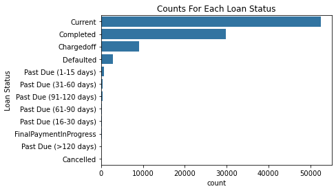

```python
# Définir la couleur par défaut de la palette de couleurs
base_color = sb.color_palette()[0]
# Utilisation de Countplot pour la distribution
data_order = df.LoanStatus.value_counts().index
sb.countplot(data = df, y = 'LoanStatus', color = base_color, order = data_order)
plt.title('Counts For Each Loan Status');
plt.ylabel('Loan Status');
```

#### Question 2 : Quel "Duree" compte le plus grand nombre de prêts dans l'ensemble de données ?

```python
# Obtenons la valeur compte de chaque Durrée
df.Duree.value_counts()
```

```
36    71615
60    23141
12     1415
Name: Duree, dtype: int64
```

#### Visualisation

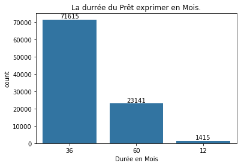

```python
# Utilisation de Barplot pour cette distribution
term_order = df.Duree.value_counts().index
sb.countplot(x='Duree', data = df, color = base_color, order = term_order)
plt.title('La durrée du Prêt exprimer en Mois.');
plt.xlabel('Durée en Mois')
# Ajout du nombre de chaque terme dans nos données au-dessus de chaque barre.
for i in range (df.Duree.value_counts().shape[0]):
    Nombre = df.Duree.value_counts().values[i]
    plt.text(i, Nombre+3500, Nombre, ha = 'center', va='top')
```

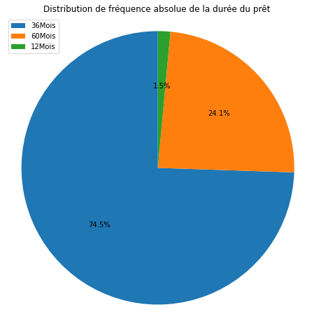

```python
# Créer un diagramme circulaire pour montrer la distribution
plt.figure(figsize=[8,8])
c = df.Duree.value_counts()
labels = '36Mois','60Mois','12Mois'
plt.pie(c, autopct='%1.1f%%', startangle=90)
plt.title('Distribution de fréquence absolue de la durée du prêt')
plt.axis('square')
plt.legend(labels);
```

#### Observation

> D'après le graphique ci-dessus, nous pouvons voir que la majorité des personnes qui ont contracté des prêts ont opté pour le plan de 36 mois. Donc une proportion plus élevée de prêts ont été approuvés pour une période de 36 mois, tandis qu'une proportion moindre a été approuvée pour une période de 60 mois avec une très faible proportion de prêts approuvés pour une période de 12 mois. Nous pouvons donc maintenant nous poser la question de savoir quel type de prêts ont été approuvés pour la période de 36 mois par rapport aux prêts approuvés pour 60 et 12 mois respectivement.

#### Question 3 : Quelle relation ou modèle existe-t-il dans `CategoryEmp` ?

```python
# Observons les différentes valeurs de catégorie
df.CategorieEmp.value_counts()
```

```
DebtConsolidation    54603
Other                 9526
N/A                   7484
HomeImprovement       6958
Business              5197
Auto                  2360
PersonalLoan          2259
HouseholdExpenses     1787
Medical/Dental        1404
LargePurchases         806
Taxes                  788
WeddingLoans           731
Vacation               722
StudentUse             604
Motorcycle             289
EngagementRing         201
Baby&Adoption          191
Boat                    83
CosmeticProcedure       82
RV                      50
GreenLoans              46
Name: CategorieEmp, dtype: int64
```

#### Visualisation

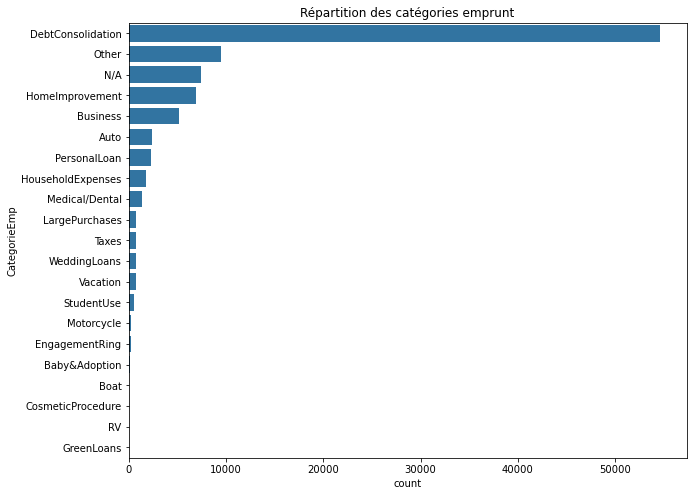

```python
# utilisons la fonction countplot
listCat = df.CategorieEmp.value_counts()
plt.figure(figsize=(10,8))
sb.countplot(y='CategorieEmp',data=df,order=listCat.index, color = base_color)
plt.title('Répartition des catégories emprunt');
```

#### Observation

> Il ressort du graphique ci-dessus que la consolidation de dettes compte le plus. Cela indique que les personnes de cette catégorie ont reçu le plus de prêts. Cela pourrait impliquer qu'un grand nombre d'emprunteurs avaient déjà des dettes, ils se sont donc tournés vers des prêts de consolidation de dettes pour réduire le poids de ces dettes et payer un petit montant pour un nouveau prêt chaque mois à un faible taux d'intérêt.

#### Question 4 : Quelle relation ou modèle existe-t-il dans `Interet` ?

```python
# Visualisons les données statistiques des intérêts
df.Interet.describe()
```

```
count    96171.000000
mean         0.190933
std          0.074653
min          0.000000
25%          0.131400
50%          0.180000
75%          0.249200
max          0.360000
Name: Interet, dtype: float64
```

#### Visualisation

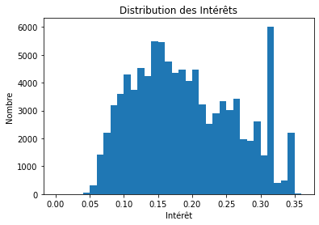

```python
bin_edges = np.arange(0,df.Interet.max()+0.01,0.01)
plt.hist(x='Interet', data = df, bins = bin_edges)
plt.title('Distribution des Intérêts')
plt.xlabel('Intérêt')
plt.ylabel('Nombre');
```

#### Observation

> La distribution ci-dessus a deux pics, l'un entre 0,12 et 0,15 et l'autre entre 0,30 et 0,33, ce qui en fait une distribution bimodale. La distribution est asymétrique à droite. Le nombre d'emprunteurs diminue après le taux de 0,16, mais augmente ensuite soudainement dans la fourchette de taux de 0,32 et 0,34.

#### Question 5: Quel relation présente `IncomeRange`?

```python
# Observons les différentes valeurs de IncomeRange
df.IncomeRange.value_counts()
```

```
$25,000-49,999    29204
$50,000-74,999    28942
$100,000+         15906
$75,000-99,999    15834
$1-24,999          6128
Not displayed       101
Not employed         56
$0                    0
Name: IncomeRange, dtype: int64
```

#### Visualisation

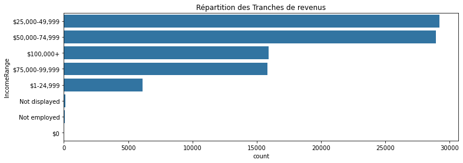

```python
# utilisons la fonction countplot
listInc = df.IncomeRange.value_counts()
plt.figure(figsize=(12,4))
sb.countplot(y='IncomeRange',data=df,order=listInc.index, color = base_color)
plt.title('Répartition des Tranches de revenus');
```

#### Observation

> Un examen attentif de la distribution IncomeRange montre clairement que les emprunteurs dont les revenus se situaient entre 25 000 et 74 999 dollars avaient le taux de prêts le plus élevé obtenu auprès de Prosper. Nous pouvons également voir que même les emprunteurs qui n'ont pas d'emploi ont obtenu des prêts ainsi qu'un partie non déclaré, bien qu'une très faible proportion d'emprunteurs dans cette catégorie. Et que ceux n'ayant gagné aucun revenu n'ont eu droit à rien.

#### Question 6 : Quelle relation ou modèle existe-t-il dans "AdresseAnnonce" ?

```python
# Visualisé et créer une liste de donnée d'adresse d'annonce
col = df.AdresseAnnonce.value_counts()
col
```

```
CA    12835
NY     6002
FL     5886
TX     5710
IL     5313
GA     4341
OH     3906
MI     3171
VA     2979
NJ     2809
NC     2745
PA     2712
WA     2648
MD     2598
MO     2268
MN     2118
MA     2038
CO     1955
IN     1876
AZ     1678
WI     1644
TN     1586
OR     1538
CT     1492
AL     1484
NV     1001
SC      996
KS      951
KY      910
OK      871
LA      854
AR      778
UT      737
MS      717
NE      607
ID      515
NH      502
NM      409
RI      405
DC      363
HI      357
WV      345
MT      283
DE      282
VT      192
AK      181
SD      166
IA      160
WY      133
ME       83
ND       41
Name: AdresseAnnonce, dtype: int64
```

#### Visualisation

[figure not shown]

```python
plt.figure(figsize=(12,14))
sb.countplot(y='AdresseAnnonce',data=df,order=col.index, color = base_color)
plt.title('Distribution suivant des adresses annonce de prêt');
```

#### Observation

> D'après le graphique ci-dessus, nous pouvons voir que l'État avec le plus d'emprunteurs est la Californie. Et celle qui en a le moins est ND

#### Question 7 : Quelle relation ou modèle existe-t-il dans `EmploymentStatus` ?

```python
# Visualisé et créer une liste de donnée d'adresse d'annonce
St = df.EmploymentStatus.value_counts()
St
```

```
Employed         65895
Full-time        24109
Other             3520
Self-employed      993
Part-time          884
Retired            702
Not employed        68
Not available        0
Name: EmploymentStatus, dtype: int64
```

#### Visualisation

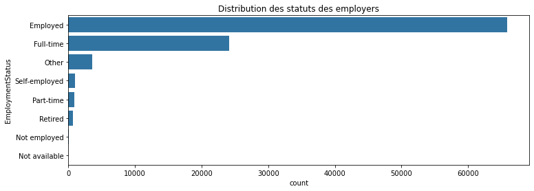

```python
plt.figure(figsize=(12,4))
sb.countplot(y='EmploymentStatus',data=df,order=St.index, color = base_color)
plt.title('Distribution des statuts des employers');
```

#### Observation

> Une supposition aléatoire aurait facilement prédit que plus de personnes employées obtiendraient des prêts que les personnes sans emploi, retraitées, travaillant à temps partiel et autres formes d'emploi sans revenu fixe. Cela va de soi, comme le montre la répartition du statut d'emploi ci-dessus. Cette distribution peut cependant aider à répondre à la question de la taille des prêts offerts aux chômeurs, aux retraités et aux emprunteurs à temps partiel par rapport aux emprunteurs en emploi, à temps plein et indépendants.

#### Question 8: La cinquième variable prédictive est de savoir quelles catégories d'emprunteurs sont propriétaires et ceux qui ne le sont pas. Ce facteur est-il responsable de l'obtention de prêts ? et dans quelle mesure cela affecte-t-il l'obtention de prêts ?

```python
# Visualisé et créer une liste de donnée d'adresse d'annonce
df.ProprietaireEmp.value_counts()
```

```
True     51006
False    45165
Name: ProprietaireEmp, dtype: int64
```

#### Visualisation

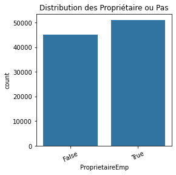

```python
plt.figure(figsize=(4,4))
sb.countplot(x='ProprietaireEmp',data=df,color=base_color)
plt.xticks(rotation=25)
plt.title('Distribution des Propriétaire ou Pas');
```

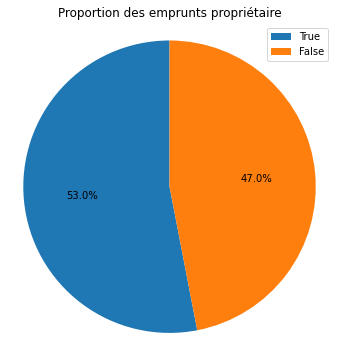

```python
# Créer une distribution Circulaire des emprunts sur propriété
plt.figure(figsize=[8,6])
count = df.ProprietaireEmp.value_counts()
labels=count.index
plt.pie(count, autopct='%1.1f%%', startangle=90)
plt.axis('square')
plt.title('Proportion des emprunts propriétaire')
plt.legend(labels);
```